# Plastic Pirates EU Analsysis

Dr. Antonio Canepa-Oneto & Dr. Patricia De La Fuente-Gamero

2026-11-10

# Data Analysis

## Loading Packages

Loading R packages necessary to perform the **EDA**.

## RESEARCH QUESTIONS

### Citizens Description

#### Numer of samplings per year and country

- Table

| CountryResponsible | SamplingYear | Num_Sampling |
| --- | --- | --- |
| austria | 2022 | 13 |
| austria | 2023 | 54 |
| austria | 2024 | 62 |
| belgium | 2022 | 22 |
| belgium | 2024 | 31 |
| bulgaria | 2023 | 10 |
| germany | 2022 | 73 |
| germany | 2023 | 11 |
| germany | 2024 | 6 |
| greece | 2022 | 8 |

[output cut: 18 more lines]

- Plot

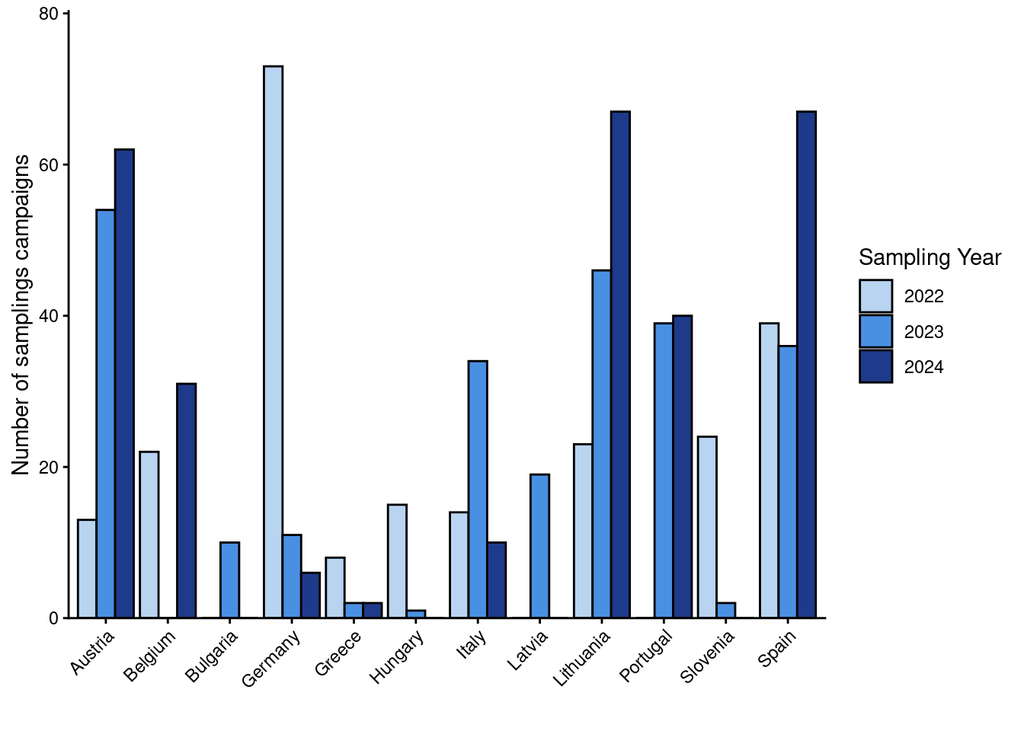

#### Numer of Rivers sampled per year and country

- Table

| CountryResponsible | SamplingYear | Rivers |
| --- | --- | --- |
| austria | 2022 | 10 |
| austria | 2023 | 35 |
| austria | 2024 | 35 |
| belgium | 2022 | 12 |
| belgium | 2024 | 18 |
| bulgaria | 2023 | 1 |
| germany | 2022 | 58 |
| germany | 2023 | 10 |
| germany | 2024 | 5 |
| greece | 2022 | 7 |

[output cut: 18 more lines]

- Plot (without numbers)

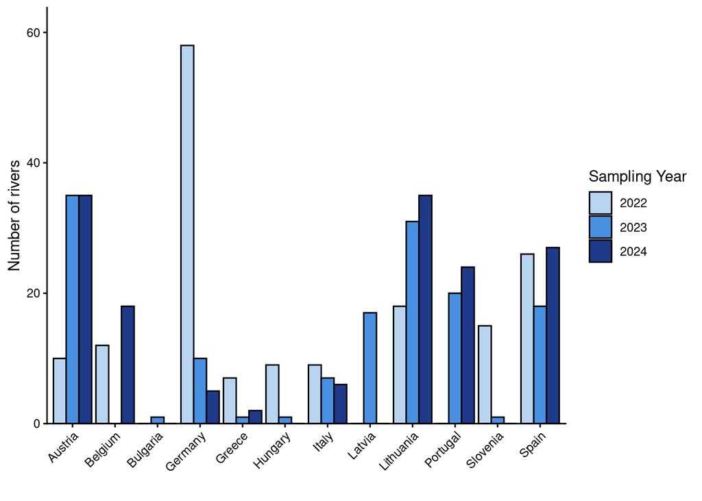

- Plot (with numbers)

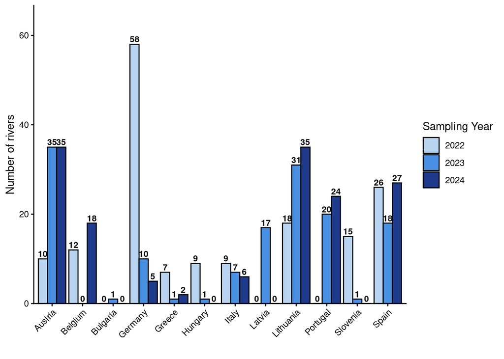

Crearemos una sola figura con las dos gráficas.

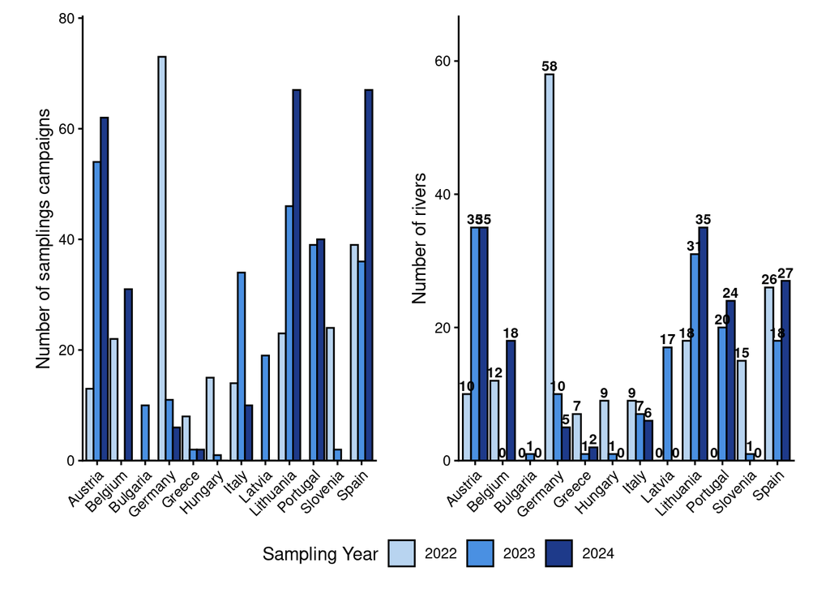

### Sampling Effort Description

The sampling effort of each Group B survey is defined by the size of the riverbank area searched, recorded in two attributes:

- `RiversideWasteVariety_Results_LengthOfRiverbankSearchedM`: length of the riverbank searched (m).
- `RiversideWasteVariety_Results_WidthOfRiverbankSearchedM`: width of the riverbank searched (m).

According to the dataset documentation (`READme_info_riverbank_v2.0.0.txt`), *“Data for length and width of riverbank searched for group B could not always be verified by the experts”*. Therefore, before using them (e.g. to standardise litter counts per m²), we describe (i) the amount of missing values and (ii) their variability, looking for outliers.

**Note:** the CSV codes missing values both as `"na"` and as `"NA"`. Both are declared as missing in `DataLoading` (`na.strings = c("na", "NA")`), so length and width are read as numeric. Otherwise, the width attribute would be read as text because of the literal `"NA"` cells.

#### Missing values

For each attribute we count the missing values (`NA`), and for the combination of both we count the *complete cases* (rows with both length and width). The *Incomplete* columns show how many records, and what percentage of the total, would be removed if we kept only complete cases. This is shown for the whole dataset, for the attempted samplings and for the validated Group B samplings (the subset used in the analyses).

| Subset | N | NA Length (n) | NA Length (%) | NA Width (n) | NA Width (%) | NA Both (n) | Incomplete (n) | Incomplete (%) | Complete cases (n) | Complete cases (%) |
| --- | --- | --- | --- | --- | --- | --- | --- | --- | --- | --- |
| All records | 770 | 84 | 10.9 | 82 | 10.6 | 74 | 92 | 11.9 | 678 | 88.1 |
| Attempted sampling | 742 | 56 | 7.5 | 54 | 7.3 | 46 | 64 | 8.6 | 678 | 91.4 |
| Validated (Group B) | 545 | 8 | 1.5 | 14 | 2.6 | 7 | 15 | 2.8 | 530 | 97.2 |

In the validated Group B dataset, 15 out of 545 samplings (2.8%) lack the length, the width or both. Keeping only complete cases would remove that share of the data.

Missing values per country (validated Group B samplings), to check whether they are concentrated in a few countries:

| CountryResponsible | N | NA Length (n) | NA Width (n) | Incomplete (n) | Incomplete (%) |
| --- | --- | --- | --- | --- | --- |
| Italy | 51 | 2 | 5 | 5 | 9.8 |
| Slovenia | 24 | 1 | 1 | 2 | 8.3 |
| Portugal | 45 | 2 | 3 | 3 | 6.7 |
| Germany | 84 | 1 | 3 | 3 | 3.6 |
| Spain | 86 | 2 | 2 | 2 | 2.3 |
| Austria | 70 | 0 | 0 | 0 | 0.0 |
| Belgium | 49 | 0 | 0 | 0 | 0.0 |
| Bulgaria | 10 | 0 | 0 | 0 | 0.0 |
| Greece | 11 | 0 | 0 | 0 | 0.0 |
| Hungary | 15 | 0 | 0 | 0 | 0.0 |

[output cut: 2 more lines]

#### Variability and outliers

Descriptive statistics of the validated Group B samplings. Zero values are also counted, since a searched length or width of 0 m is not plausible.

Both attributes are strongly concentrated around a few “standard” values (most samplings searched about 50 m × 20 m) and have long right tails. Under these conditions Tukey’s IQR rule is not useful: the width IQR is very narrow (15–20 m), so the rule flags around a quarter of the samplings as outliers, even on a log scale. Instead, we flag as **extreme values** those below the lower or above the upper percentile set in `pct_limits` (by default the 1st and 99th percentiles), plus all zero values. The limits can be changed to make the criterion more or less strict.

| Variable | n | NA | Zeros | Min | P_low | Q1 | Median | Mean | Q3 | P_high | Max | Extreme (n) |
| --- | --- | --- | --- | --- | --- | --- | --- | --- | --- | --- | --- | --- |
| Length_m | 537 | 8 | 2 | 0 | 7.2080 | 40 | 50 | 91.4 | 85 | 700 | 1370 | 11 |
| Width_m | 531 | 14 | 2 | 0 | 2.0000 | 15 | 20 | 24.3 | 20 | 100 | 1500 | 6 |
| Area_m2 | 530 | 15 | 2 | 0 | 36.7076 | 600 | 1000 | 4286.6 | 1600 | 16988 | 1050000 | 12 |

Both attributes are strongly right-skewed (the mean is much higher than the median), so the histograms use a logarithmic x-axis. Zero values cannot be shown on a log scale and are excluded from the plots (they are counted in the table above). The solid line marks the median and the dashed lines the percentile limits. The scatter plot combines both attributes; the grey diagonal lines show constant searched areas (100, 1,000, 10,000 and 100,000 m²).

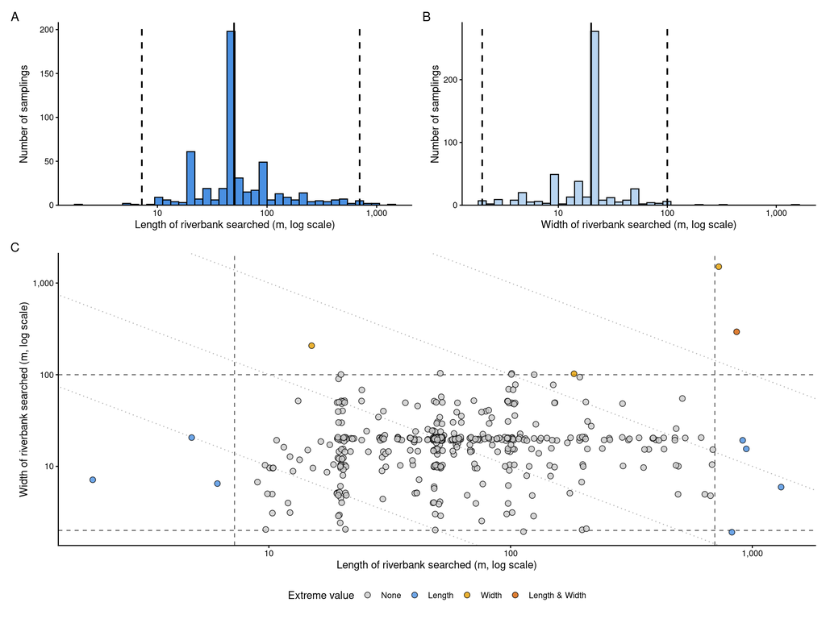

Distribution of length and width per country, to check whether outliers are specific to some countries (zero values excluded):

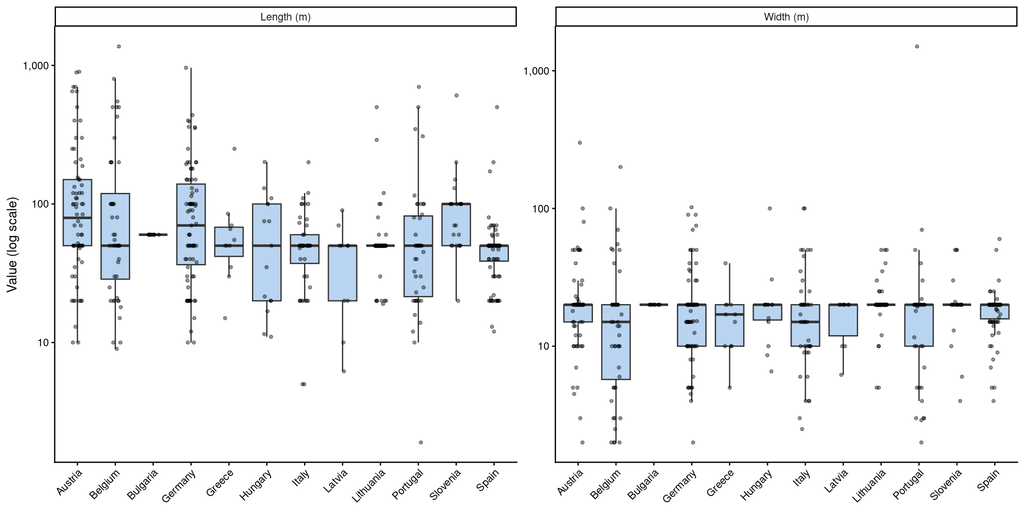

List of the validated samplings with extreme values (outside the percentile limits, or zero) in length or width, ordered by searched area, for manual checking:

| DatasetID | CountryResponsible | SamplingYear | SamplingRiver | Length_m | Width_m | Area_m2 | Extreme |
| --- | --- | --- | --- | --- | --- | --- | --- |
| pt_6762 | Portugal | 2023 | Pinhão River | 700.0 | 1500.0 | 1.050e+06 | Width |
| at_6953 | Austria | 2023 | Halterbach | 900.0 | 300.0 | 2.700e+05 | Length & Width |
| de_6249 | Germany | 2022 | Lauter River | 180.0 | 102.0 | 1.836e+04 | Width |
| at_7163 | Austria | 2024 | Ager | 890.0 | 20.0 | 1.780e+04 | Length |
| de_6326 | Germany | 2022 | Hunte River | 962.0 | 15.0 | 1.443e+04 | Length |
| be_6325 | Belgium | 2022 | Scheldt River | 1370.0 | 6.0 | 8.220e+03 | Length |
| be_7292 | Belgium | 2024 | Kleine Nete | 15.0 | 200.0 | 3.000e+03 | Width |
| be_6444 | Belgium | 2022 | Yser River | 800.0 | 2.0 | 1.600e+03 | Length |
| it_6572 | Italy | 2022 | Tiber River | 5.0 | 20.0 | 1.000e+02 | Length |
| lv_7074 | Latvia | 2023 | Vaive | 6.2 | 6.2 | 3.844e+01 | Length |

[output cut: 4 more lines]

### Most common types and quantities of litter per region? (Group B: riverbanks; Group C: floating litter)

#### Group B: Riverside Waste

Statistics of the variable `RiversideWasteVariety_AttemptedSampling` to see how many samplings were performed.

```
## RiversideWasteVariety_AttemptedSampling
##   0   1
##  26 742
```

To work with the `RiversideWasteVariety_` data, we need to filter the dataset to include only those rows where `RiversideWasteVariety_AttemptedSampling` is 1 (indicating that a sampling was attempted) and `RiversideWasteVariety_Qualified` is also 1 (indicating that the sampling was qualified).

##### Percentage of qualified samplings

| total_rows | total_valid | pct_valid_total | pct_valid_percent |
| --- | --- | --- | --- |
| 770 | 545 | 70.8 | 70.8% |

| CountryResponsible | total_rows | total_valid | pct_valid_total(%) | total_attempts | valid_among_attempts | pct_valid_among_attempts(%) |
| --- | --- | --- | --- | --- | --- | --- |
| Austria | 129 | 70 | 54.3 | 116 | 70 | 60.3 |
| Belgium | 53 | 49 | 92.5 | 52 | 49 | 94.2 |
| Bulgaria | 10 | 10 | 100.0 | 10 | 10 | 100.0 |
| Germany | 90 | 84 | 93.3 | 89 | 84 | 94.4 |
| Greece | 12 | 11 | 91.7 | 11 | 11 | 100.0 |
| Hungary | 16 | 15 | 93.8 | 16 | 15 | 93.8 |
| Italy | 58 | 51 | 87.9 | 55 | 51 | 92.7 |
| Latvia | 19 | 10 | 52.6 | 19 | 10 | 52.6 |
| Lithuania | 136 | 90 | 66.2 | 133 | 90 | 67.7 |
| Portugal | 79 | 45 | 57.0 | 77 | 45 | 58.4 |

[output cut: 2 more lines]

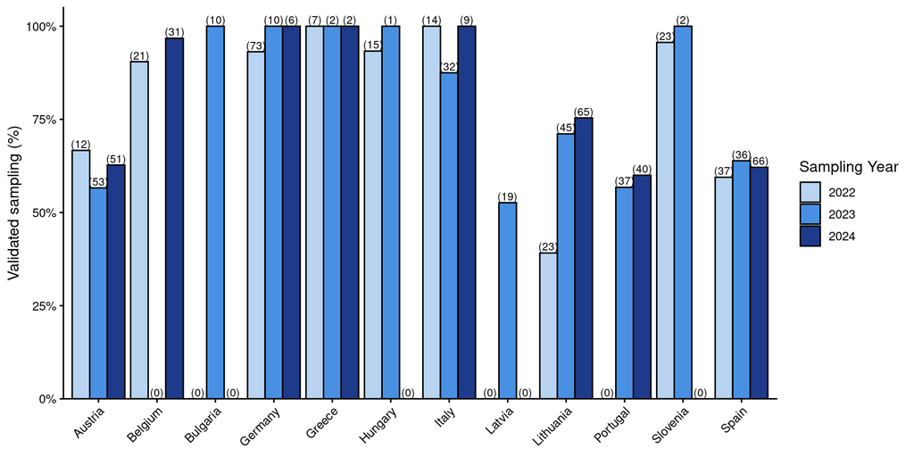

###### Manuscript values: validation rates (Sampling Effort)

Validation rate (% of attempted Group B samplings that were validated) per country and year, as in Fig. 2C, and the lowest rate among the countries described in the manuscript as having high validation rates.

| CountryResponsible | 2022 | 2023 | 2024 |
| --- | --- | --- | --- |
| Austria | 66.7 | 56.6 | 62.7 |
| Belgium | 90.5 | NA | 96.8 |
| Bulgaria | NA | 100.0 | NA |
| Germany | 93.2 | 100.0 | 100.0 |
| Greece | 100.0 | 100.0 | 100.0 |
| Hungary | 93.3 | 100.0 | NA |
| Italy | 100.0 | 87.5 | 100.0 |
| Latvia | NA | 52.6 | NA |
| Lithuania | 39.1 | 71.1 | 75.4 |
| Portugal | NA | 56.8 | 60.0 |

[output cut: 2 more lines]

| CountryResponsible | SamplingYear | n_attempted | n_validated | pct_validated |
| --- | --- | --- | --- | --- |
| Italy | 2023 | 32 | 28 | 87.5 |
| Belgium | 2022 | 21 | 19 | 90.5 |
| Germany | 2022 | 73 | 68 | 93.2 |
| Hungary | 2022 | 15 | 14 | 93.3 |
| Slovenia | 2022 | 23 | 22 | 95.7 |

##### Most common types/quantities of litter

Firstly, we will pick up data to answer the question about group B. Only some variables are taken from the general dataset.

The, Attributes’ names are so complicated to work that I’ll remote the preceding information **RiversideWasteVariety_Results_** which is common to all attributes; and finally to work with only the validated `Group B` dataset we create:

**CAUTION**! There are some `NAs` values in the litter items that are probably incorrect since the groups did find other items.

After meeting and email from Charlotte, we realise that NA in group B for some items it’s really a zero. So we update these columns replacing `NA` values with a `0`.

###### Litter type abundance

We will obtain the plot for the most common (average abundance) litter type, as a table and then as a plot.

|  | Litter_type | Av_Abundance | SE_Abundance |
| --- | --- | --- | --- |
| 1 | CigaretteButts | 23.41 | 2.57 |
| 2 | GlassPieces | 17.22 | 3.98 |
| 3 | OtherUnidentifiablePlastic | 12.08 | 1.39 |
| 4 | WetWipesSanitaryProducts | 12.07 | 4.52 |
| 5 | Paper | 10.67 | 0.75 |
| 6 | PlasticPackagingSweets | 9.91 | 0.67 |
| 7 | SmallPlasticPieces.2.5cm | 9.26 | 1.96 |
| 8 | PlasticBags | 7.54 | 0.69 |
| 9 | Polystyrene | 6.55 | 1.36 |
| 10 | PlasticBottles | 6.31 | 1.3 |

[output cut: 15 more lines]

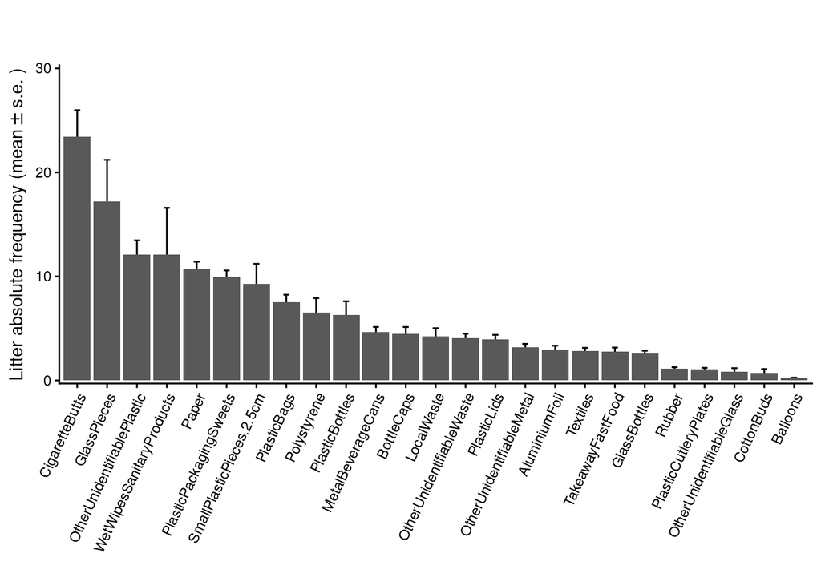

###### Litter type abundance per country

If we now want to visualize the contribution per each country, we have:

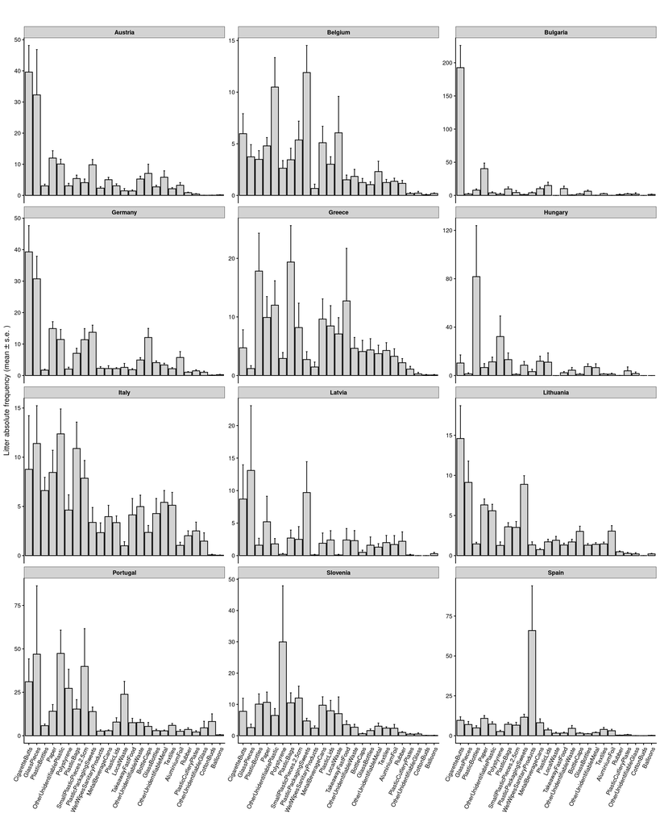

###### Manuscript values: mean ± s.e. and n (Fig. 3 and Fig. 4)

Mean ± standard error (rounded to one decimal) and number of validated samplings (*n*) for the litter categories and countries cited in the Results section.

| Litter_type | n | Mean | SE | Manuscript |
| --- | --- | --- | --- | --- |
| CigaretteButts | 545 | 23.41101 | 2.567505 | 23.4 ± 2.6, n = 545 |
| GlassPieces | 545 | 17.22385 | 3.980405 | 17.2 ± 4.0, n = 545 |
| OtherUnidentifiablePlastic | 545 | 12.08073 | 1.385194 | 12.1 ± 1.4, n = 545 |
| WetWipesSanitaryProducts | 545 | 12.07156 | 4.521659 | 12.1 ± 4.5, n = 545 |

| Litter_type | CountryResponsible | Manuscript |
| --- | --- | --- |
| CigaretteButts | Bulgaria | 192.6 ± 33.5, n = 10 |
| CigaretteButts | Austria | 39.6 ± 8.5, n = 70 |
| CigaretteButts | Germany | 39.3 ± 8.4, n = 84 |
| CigaretteButts | Lithuania | 14.6 ± 4.1, n = 90 |
| GlassPieces | Austria | 32.3 ± 14.6, n = 70 |
| GlassPieces | Germany | 30.7 ± 7.2, n = 84 |
| GlassPieces | Italy | 11.4 ± 3.8, n = 51 |
| GlassPieces | Portugal | 46.9 ± 39.4, n = 45 |
| GlassPieces | Lithuania | 9.1 ± 2.7, n = 90 |
| PlasticBottles | Hungary | 81.7 ± 42.2, n = 15 |

[output cut: 6 more lines]

###### Litter type Proportion I - “Across‑type” proportions

- The first approach will be a “*Across‑type*” proportions.
  - For each litter type, what fraction comes from each country? (not from an european total)
  - total abundance of that litter type over each total country.

| CountryResponsible | Litter_type | Total_Abundance | Global_Total | Prop_Country |
| --- | --- | --- | --- | --- |
| austria | AluminiumFoil | 228 | 1613 | 0.1413515189 |
| austria | Balloons | 11 | 125 | 0.0880000000 |
| austria | BottleCaps | 494 | 2441 | 0.2023760754 |
| austria | CigaretteButts | 2773 | 12759 | 0.2173367819 |
| austria | CottonBuds | 4 | 394 | 0.0101522843 |
| austria | GlassBottles | 192 | 1431 | 0.1341719078 |
| austria | GlassPieces | 2260 | 9387 | 0.2407584958 |
| austria | LocalWaste | 103 | 2296 | 0.0448606272 |
| austria | MetalBeverageCans | 353 | 2521 | 0.1400238001 |
| austria | OtherUnidentifiableGlass | 3 | 462 | 0.0064935065 |

[output cut: 290 more lines]

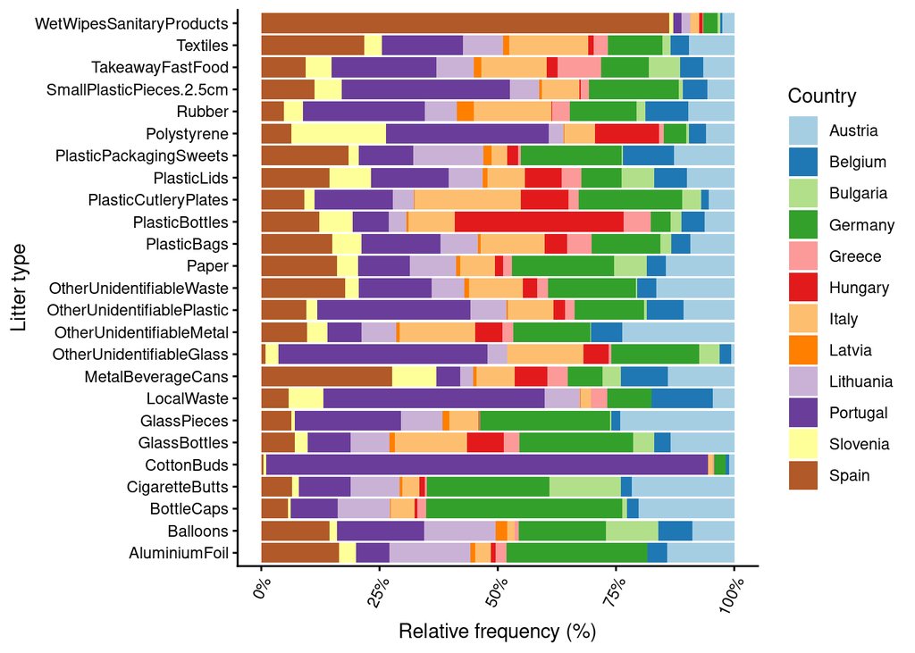

- Now, considering the total of Europe

| CountryResponsible | Litter_type | Total_Abundance | European_Total | Prop_of_Europe |
| --- | --- | --- | --- | --- |
| Austria | AluminiumFoil | 228 | 1613 | 0.1413515189 |
| Austria | Balloons | 11 | 125 | 0.0880000000 |
| Austria | BottleCaps | 494 | 2441 | 0.2023760754 |
| Austria | CigaretteButts | 2773 | 12759 | 0.2173367819 |
| Austria | CottonBuds | 4 | 394 | 0.0101522843 |
| Austria | GlassBottles | 192 | 1431 | 0.1341719078 |
| Austria | GlassPieces | 2260 | 9387 | 0.2407584958 |
| Austria | LocalWaste | 103 | 2296 | 0.0448606272 |
| Austria | MetalBeverageCans | 353 | 2521 | 0.1400238001 |
| Austria | OtherUnidentifiableGlass | 3 | 462 | 0.0064935065 |

[output cut: 290 more lines]

To compare and validate the output, for each `litter_type` the `European_Total` have to be the same.

| CountryResponsible | Litter_type | Total_Abundance | European_Total | Prop_of_Europe |
| --- | --- | --- | --- | --- |
| Austria | AluminiumFoil | 228 | 1613 | 0.1413515189 |
| Belgium | AluminiumFoil | 67 | 1613 | 0.0415375077 |
| Bulgaria | AluminiumFoil | 1 | 1613 | 0.0006199628 |
| Germany | AluminiumFoil | 481 | 1613 | 0.2982021079 |
| Greece | AluminiumFoil | 36 | 1613 | 0.0223186609 |
| Hungary | AluminiumFoil | 17 | 1613 | 0.0105393676 |
| Italy | AluminiumFoil | 53 | 1613 | 0.0328580285 |
| Latvia | AluminiumFoil | 17 | 1613 | 0.0105393676 |
| Lithuania | AluminiumFoil | 275 | 1613 | 0.1704897706 |
| Portugal | AluminiumFoil | 115 | 1613 | 0.0712957223 |

[output cut: 2 more lines]

[figure not shown]

- HeatMaps

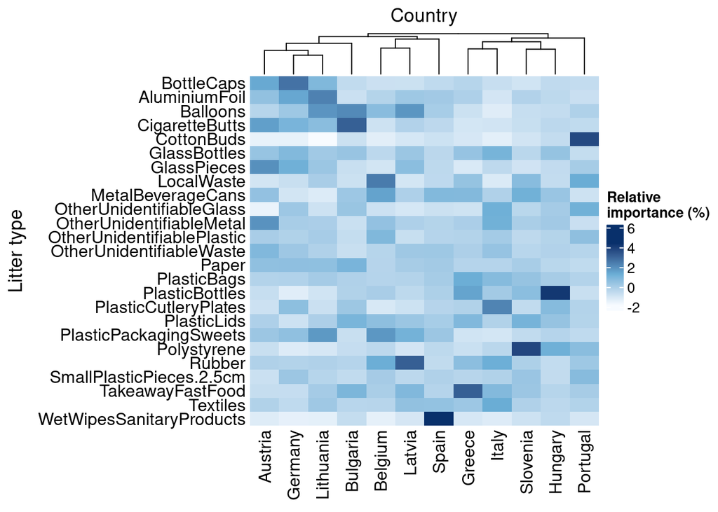

Bootstrap implementation in the dendrograms nodes. It replaces the previous heatmap with the dendrograms based on bootstrap values.

[output not shown]

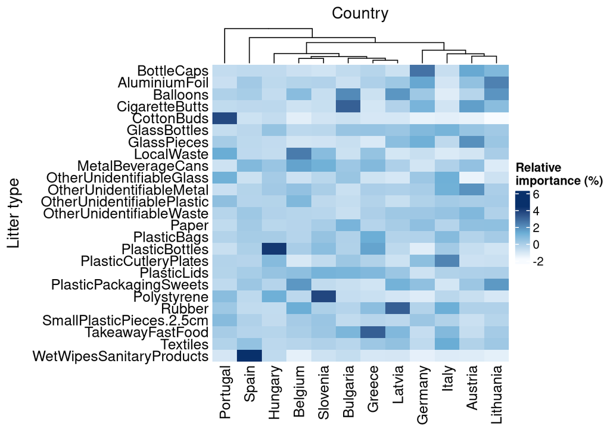

Dendrogram with the values

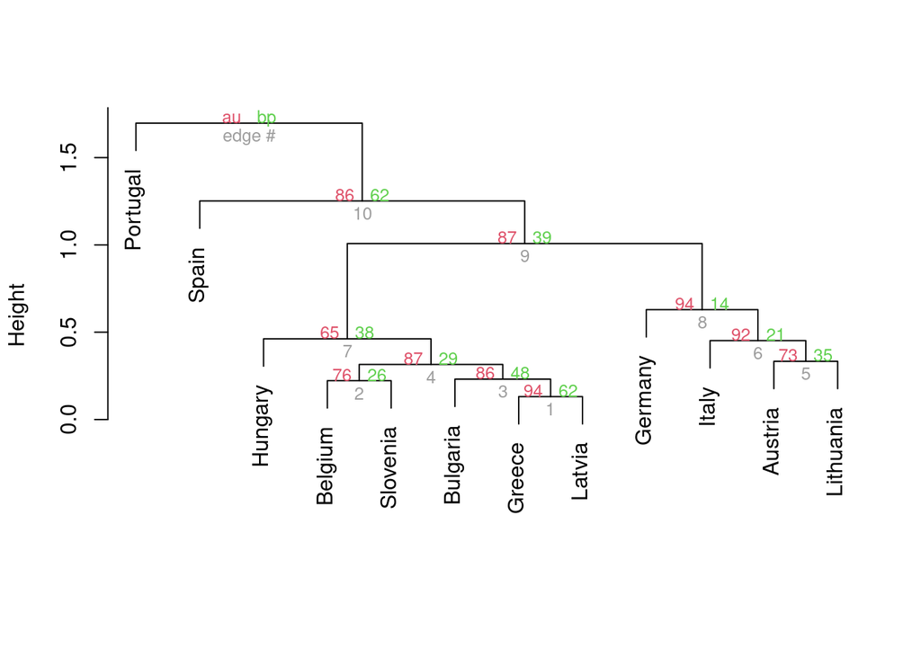

###### Multivariate Perspective

In order to see if there are significant differences across country in the community composition, we will perform a PERMANOVA test:

```
## Permutation test for adonis under reduced model
## Marginal effects of terms
## Permutation: free
## Number of permutations: 999
##
## adonis2(formula = dist_mat ~ CountryResponsible, data = meta, permutations = 999, by = "margin", na.action = na.omit)
##                     Df SumOfSqs      R2      F Pr(>F)
## CountryResponsible  11   27.362 0.09899 5.2535  0.001 ***
## Residual           526  249.052 0.90101
## Total              537  276.414 1.00000
## ---
## Signif. codes:  0 '***' 0.001 '**' 0.01 '*' 0.05 '.' 0.1 ' ' 1
```

So, we conclude that there are significant differences among countries.

We can look for **heterocedasticity** among countries (homogeneity of multivariate dispersions), since PERMANOVA can also detect differences in dispersion and not only in location:

```
##
##  Homogeneity of multivariate dispersions
##
## Call: betadisper(d = dist_mat, group = meta$CountryResponsible)
##
## No. of Positive Eigenvalues: 25
## No. of Negative Eigenvalues: 0
##
## Average distance to median:
##   austria   belgium  bulgaria   germany    greece   hungary     italy    latvia
##    0.6550    0.6981    0.3731    0.6561    0.5943    0.6351    0.7082    0.6479
## lithuania  portugal  slovenia     spain
##    0.6720    0.6830    0.6464    0.6964
##
## Eigenvalues for PCoA axes:
## (Showing 8 of 25 eigenvalues)
## PCoA1 PCoA2 PCoA3 PCoA4 PCoA5 PCoA6 PCoA7 PCoA8
## 39.70 25.03 22.93 20.66 18.41 16.90 15.74 13.57
```

```
##
## Permutation test for homogeneity of multivariate dispersions
## Permutation: free
## Number of permutations: 999
##
## Response: Distances
##            Df Sum Sq  Mean Sq      F N.Perm Pr(>F)
## Groups     11 1.1883 0.108023 6.8969    999  0.001 ***
## Residuals 526 8.2385 0.015663
## ---
## Signif. codes:  0 '***' 0.001 '**' 0.01 '*' 0.05 '.' 0.1 ' ' 1
```

The multivariate dispersion **differs significantly** among countries (betadisper; F = 6.9, p = 0.001), so part of the PERMANOVA result may reflect differences in within-country variability rather than only in composition.

But what are the items that explain these differences?

The answer will be addressed by performing a **Multivariate Random Forest**.

```
##
## Call:
##  randomForest(x = comm_hel, y = as.factor(meta$CountryResponsible),      ntree = 500, importance = TRUE)
##                Type of random forest: classification
##                      Number of trees: 500
## No. of variables tried at each split: 5
##
##         OOB estimate of  error rate: 66.17%
## Confusion matrix:
##           austria belgium bulgaria germany greece hungary italy latvia
## austria        19       4        0      14      0       0     5      0
## belgium         8       5        0       3      0       0     4      0
## bulgaria        0       0        9       0      0       1     0      0
## germany         7       2        0      38      0       0     3      0
## greece          1       0        0       0      0       0     6      0
## hungary         5       1        0       0      0       3     1      0
## italy          10       4        0       7      0       0    16      0
## latvia          0       0        0       2      0       0     0      0
## lithuania       5       1        0      26      0       0     2      0
## portugal        6       3        0       7      0       0     6      0
## slovenia        3       0        0       0      0       0     4      0
## spain          14       6        0       5      0       1     6      0
##           lithuania portugal slovenia spain class.error
## austria           8        1        0    19   0.7285714
## belgium          15        0        0    12   0.8936170
## bulgaria          0        0        0     0   0.1000000
## germany          21        7        0     6   0.5476190
## greece            0        2        0     2   1.0000000
## hungary           0        0        0     5   0.8000000
## italy             3        3        2     6   0.6862745
## latvia            5        0        0     1   1.0000000
## lithuania        41        3        0    11   0.5393258
## portugal          7       11        0     5   0.7555556
## slovenia          1        3        2    11   0.9166667
## spain            13        0        1    38   0.5476190
```

Decisions have to be taken carefully since the prediction accuracy is very low (0.34). Furthermore, the estimated error rate (OOB) is high, so conclusion have to be taken with care.

Eventhough, the more important (differential across countries) litter components are:

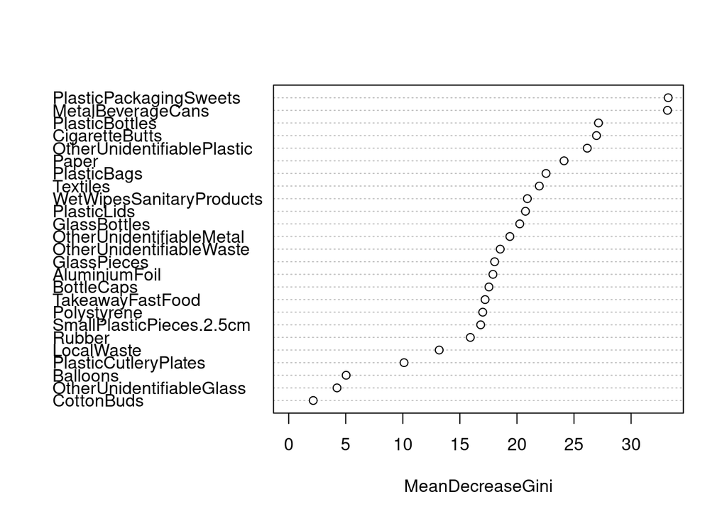

This plot of variable importance importance is telling us:

- A large `MeanDecreaseGini` (**MDG**) means that X frequently appears in high‑up the tree splits and yields big purity gains → it’s structurally important to partitioning the data.
  - **MDG** tells you which features the trees “prefer” splitting on.
- **Principal Component Analysis**

We will perform a Principal Component Analysis (PCA) to see correlation among litter items and *possible* associations with countries

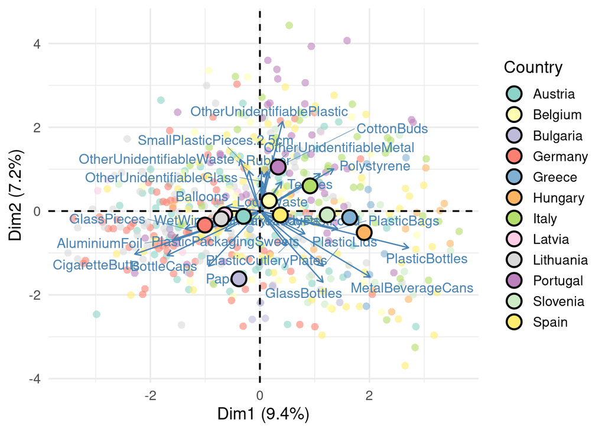

And the most important Items for the two forst principal components are:

- First PC

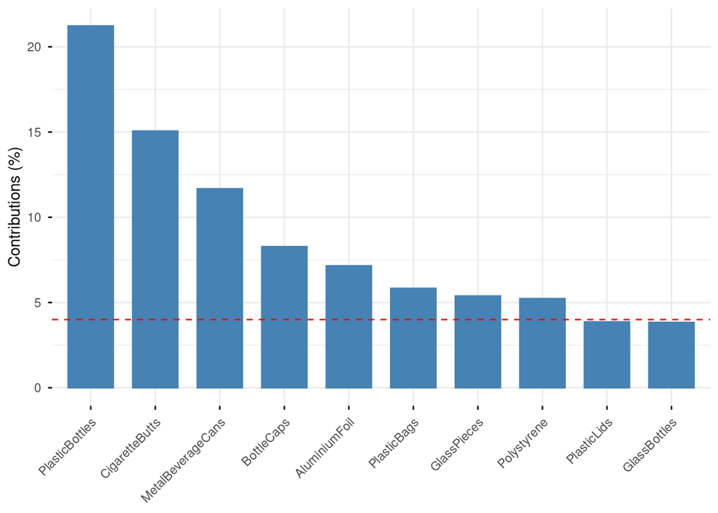

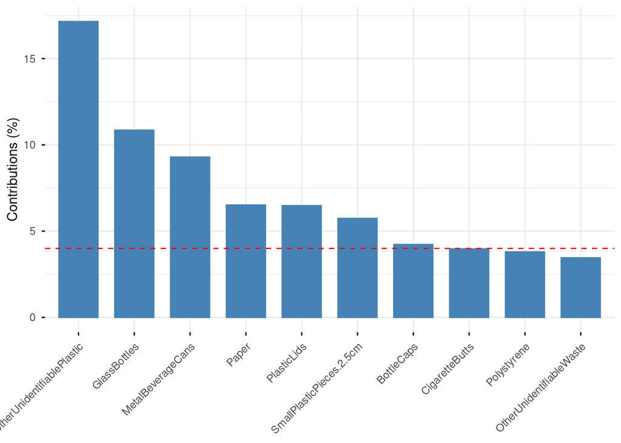

- **Non-Metric Multidimensional Scaling - nMDS**

We will perform a Non-Metric Multidimensional Scaling (nMDS) to see correlation among litter items and *possible* associations with countries.

We can re-use the distance matrix using the hellinger‐transformed data (`comm_hel`) and then perform the nMDS.

```
## [1] 0
```

```
## integer(0)
```

```
## *** Best solution was not repeated -- monoMDS stopping criteria:
##     17: no. of iterations >= maxit
##      3: stress ratio > sratmax
```

Now, we calculate the scores for the sites (samples) and add the metadata to be able to visualize the nMDS with the country information.

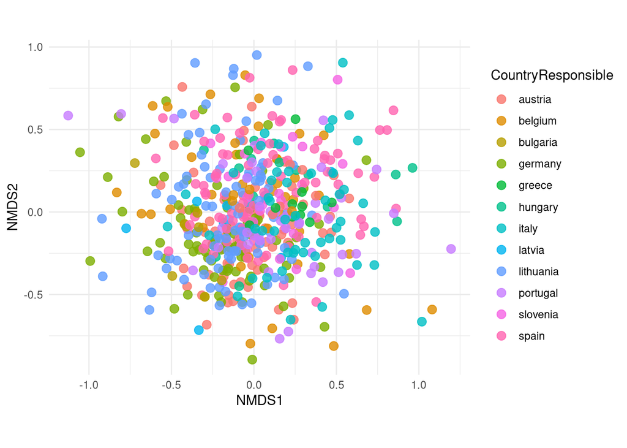

To see which countries are more similar than others, we can calculate the centroids of each country in the NMDS space and then plot them.

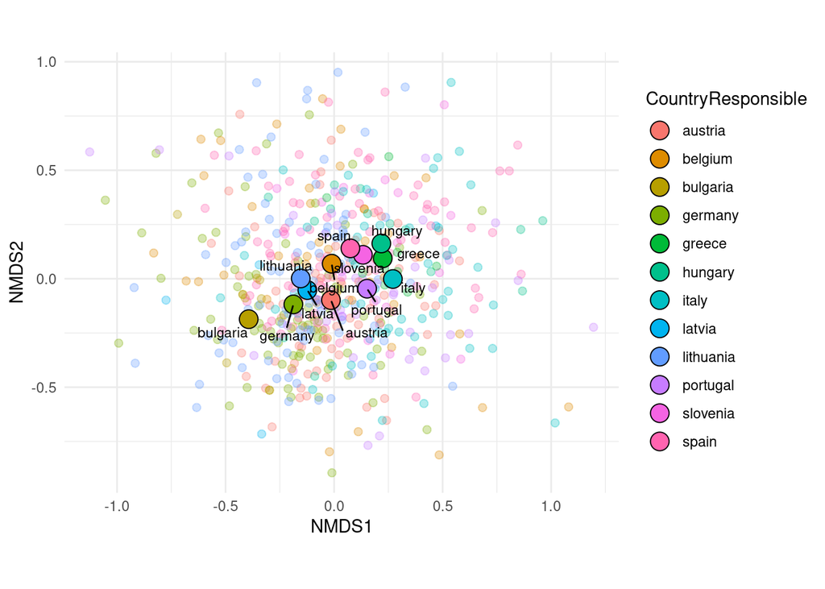

#### Group B: Single Use Plastic - Riverside Waste

We wil take as a subset the single use plastic (`SUP`) for the group B.

|  | DatasetID | CountryResponsible | SamplingCampaign | SamplingYear | SamplingCoordinatesLatitude | SamplingCoordinatesLongitude | SamplingRiverSystem | SamplingParticipants | RiversideWasteVariety_AttemptedSampling | RiversideWasteVariety_Qualified | PlasticBags | PlasticBottles | PlasticLids | TakeawayFastFood | PlasticCutleryPlates | PlasticPackagingSweets | CottonBuds | WetWipesSanitaryProducts | Polystyrene |
| --- | --- | --- | --- | --- | --- | --- | --- | --- | --- | --- | --- | --- | --- | --- | --- | --- | --- | --- | --- |
| 1 | at_6270 | austria | autumn 2022 | 2022 | 48.04275 | 14.42192 | Danube | 9 | 1 | 1 | 2 | 0 | 0 | 2 | 0 | 1 | 0 | 1 | 0 |
| 2 | at_6297 | austria | autumn 2022 | 2022 | 48.26034 | 13.03440 | Danube | 8 | 1 | 1 | 0 | 1 | 4 | 1 | 1 | 14 | 0 | 3 | 0 |
| 3 | at_6382 | austria | autumn 2022 | 2022 | 47.11828 | 13.81419 | Danube | 20 | 1 | 1 | 0 | 0 | 0 | 0 | 0 | 2 | 0 | 0 | 1 |
| 4 | at_6393 | austria | autumn 2022 | 2022 | 46.58301 | 13.84115 | Danube | 38 | 1 | 1 | 34 | 22 | 13 | 2 | 0 | 34 | 0 | 0 | 0 |
| 5 | at_6429 | austria | autumn 2022 | 2022 | 48.21108 | 16.43973 | Danube | 20 | 1 | 1 | 7 | 22 | 17 | 9 | 3 | 10 | 2 | 7 | 6 |
| 6 | at_6448 | austria | autumn 2022 | 2022 | 46.60477 | 14.27800 | Danube | 16 | 1 | 1 | 3 | 4 | 1 | 3 | 0 | 1 | 0 | 0 | 0 |

```
##    DatasetID   CountryResponsible    SamplingCampaign  SamplingYear
##  at_6270:  1   Length   :545      autumn 2021:  0     Min.   :2022
##  at_6297:  1   N.unique : 12      autumn 2022:194     1st Qu.:2022
##  at_6382:  1   N.blank  :  0      autumn 2023:142     Median :2023
##  at_6393:  1   Min.nchar:  5      autumn 2024: 50     Mean   :2023
##  at_6429:  1   Max.nchar:  9      spring 2022:  1     3rd Qu.:2024
##  at_6448:  1                      spring 2023: 26     Max.   :2024
##  (Other):539                      spring 2024:132
##  SamplingCoordinatesLatitude SamplingCoordinatesLongitude SamplingRiverSystem
##  Min.   :37.18               Min.   :-9.309               Length   :545
##  1st Qu.:42.03               1st Qu.: 2.879               N.unique : 45
##  Median :48.01               Median :12.250               N.blank  :  0
##  Mean   :47.47               Mean   :10.871               Min.nchar:  2
##  3rd Qu.:51.39               3rd Qu.:17.470               Max.nchar: 27
##  Max.   :57.75               Max.   :27.488
##
##  SamplingParticipants RiversideWasteVariety_AttemptedSampling
##  Min.   :  2.00       Min.   :1
##  1st Qu.: 13.00       1st Qu.:1
##  Median : 19.00       Median :1
##  Mean   : 19.58       Mean   :1
##  3rd Qu.: 24.00       3rd Qu.:1
##  Max.   :250.00       Max.   :1
##  NAs    :9
##  RiversideWasteVariety_Qualified  PlasticBags      PlasticBottles
##  Min.   :1                       Min.   :  0.000   Min.   :  0.000
##  1st Qu.:1                       1st Qu.:  0.000   1st Qu.:  0.000
##  Median :1                       Median :  3.000   Median :  1.000
##  Mean   :1                       Mean   :  7.543   Mean   :  6.306
##  3rd Qu.:1                       3rd Qu.:  7.000   3rd Qu.:  4.000
##  Max.   :1                       Max.   :196.000   Max.   :576.000
##
##   PlasticLids     TakeawayFastFood  PlasticCutleryPlates PlasticPackagingSweets
##  Min.   :  0.00   Min.   :  0.000   Min.   : 0.000       Min.   :  0.00
##  1st Qu.:  0.00   1st Qu.:  0.000   1st Qu.: 0.000       1st Qu.:  1.00
##  Median :  1.00   Median :  0.000   Median : 0.000       Median :  4.00
##  Mean   :  3.96   Mean   :  2.791   Mean   : 1.048       Mean   :  9.91
##  3rd Qu.:  4.00   3rd Qu.:  2.000   3rd Qu.: 1.000       3rd Qu.: 11.00
##  Max.   :115.00   Max.   :102.000   Max.   :49.000       Max.   :121.00
##
##    CottonBuds       WetWipesSanitaryProducts  Polystyrene
##  Min.   :  0.0000   Min.   :   0.00          Min.   :  0.000
##  1st Qu.:  0.0000   1st Qu.:   0.00          1st Qu.:  0.000
##  Median :  0.0000   Median :   0.00          Median :  0.000
##  Mean   :  0.7229   Mean   :  12.07          Mean   :  6.554
##  3rd Qu.:  0.0000   3rd Qu.:   2.00          3rd Qu.:  2.000
##  Max.   :145.0000   Max.   :1897.00          Max.   :423.000
##
```

###### SUP type abundance

We will obtain the plot for the most common (average abundance) Single Use Plastic type

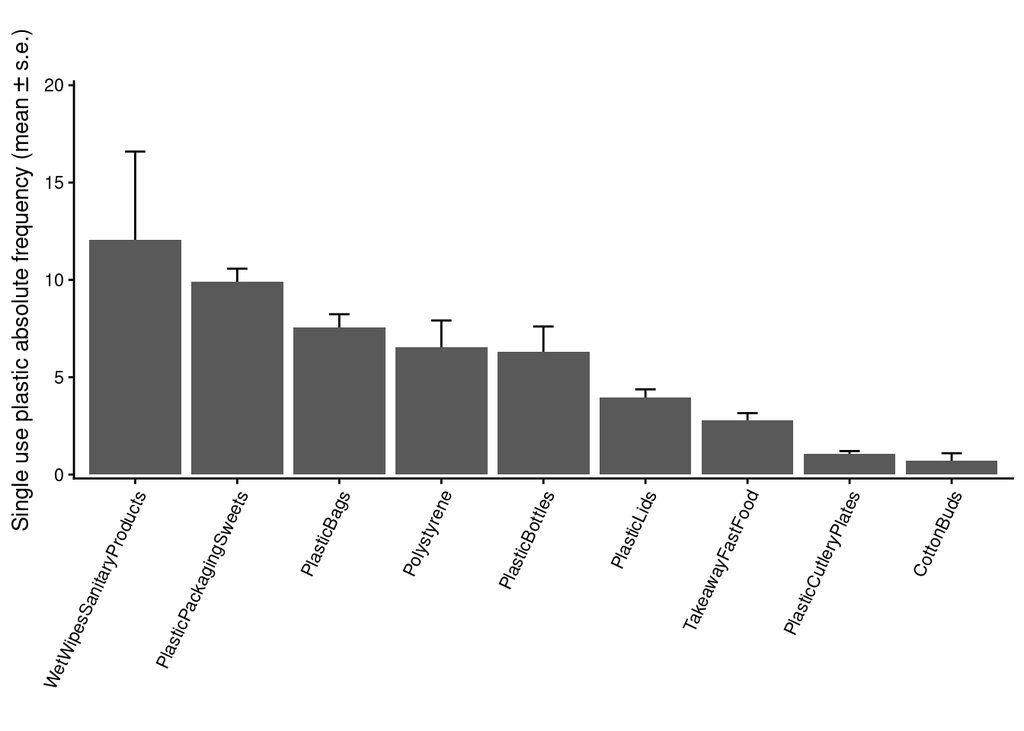

###### SUP type abundance per country

If we now want to visualize the contribution per each country, we have:

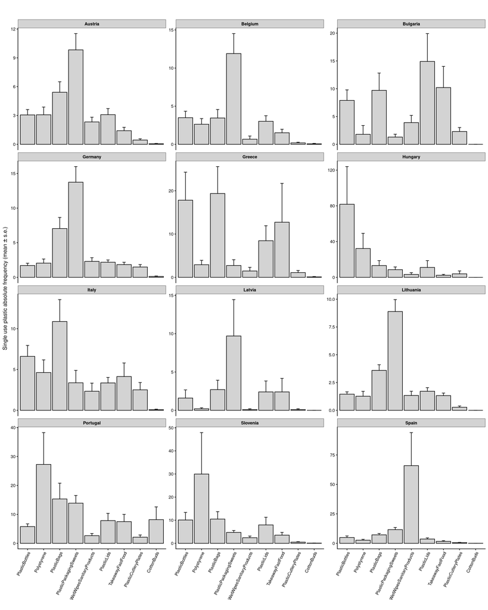

###### Manuscript values: SUP mean ± s.e. and n (Fig. 8 and Fig. 9)

Mean ± standard error (one decimal) and *n* for the SUP categories and countries cited in the Results section (uses `litter_mean_se()`, defined in the Group B section).

| Litter_type | n | Mean | SE | Manuscript |
| --- | --- | --- | --- | --- |
| WetWipesSanitaryProducts | 545 | 12.071560 | 4.5216590 | 12.1 ± 4.5, n = 545 |
| PlasticPackagingSweets | 545 | 9.910092 | 0.6653897 | 9.9 ± 0.7, n = 545 |
| PlasticBags | 545 | 7.543119 | 0.6926471 | 7.5 ± 0.7, n = 545 |

| Litter_type | CountryResponsible | Manuscript |
| --- | --- | --- |
| PlasticBags | Italy | 10.9 ± 2.7, n = 51 |
| PlasticBags | Greece | 19.4 ± 6.2, n = 11 |
| Polystyrene | Portugal | 27.3 ± 11.0, n = 45 |
| Polystyrene | Slovenia | 30.0 ± 18.0, n = 24 |
| PlasticBottles | Hungary | 81.7 ± 42.2, n = 15 |
| PlasticBottles | Greece | 17.8 ± 6.5, n = 11 |
| PlasticLids | Bulgaria | 14.9 ± 5.0, n = 10 |
| TakeawayFastFood | Bulgaria | 10.2 ± 3.8, n = 10 |

###### SUP type Proportion I - “Across‑type” proportions

- The first approach will be a “*Across‑type*” proportions.
  - total abundance of that litter type over each total country.

| CountryResponsible | Litter_type | Total_Abundance | Global_Total | Prop_Country |
| --- | --- | --- | --- | --- |
| austria | CottonBuds | 4 | 394 | 0.0101522843 |
| austria | PlasticBags | 379 | 4111 | 0.0921916809 |
| austria | PlasticBottles | 214 | 3437 | 0.0622636020 |
| austria | PlasticCutleryPlates | 31 | 571 | 0.0542907180 |
| austria | PlasticLids | 216 | 2158 | 0.1000926784 |
| austria | PlasticPackagingSweets | 688 | 5401 | 0.1273838178 |
| austria | Polystyrene | 215 | 3572 | 0.0601903695 |
| austria | TakeawayFastFood | 99 | 1521 | 0.0650887574 |
| austria | WetWipesSanitaryProducts | 163 | 6579 | 0.0247758018 |
| belgium | CottonBuds | 3 | 394 | 0.0076142132 |

[output cut: 98 more lines]

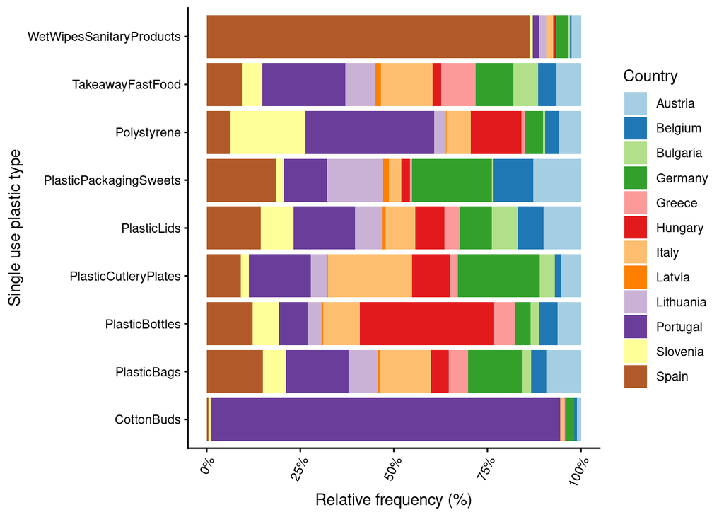

- HeatMaps

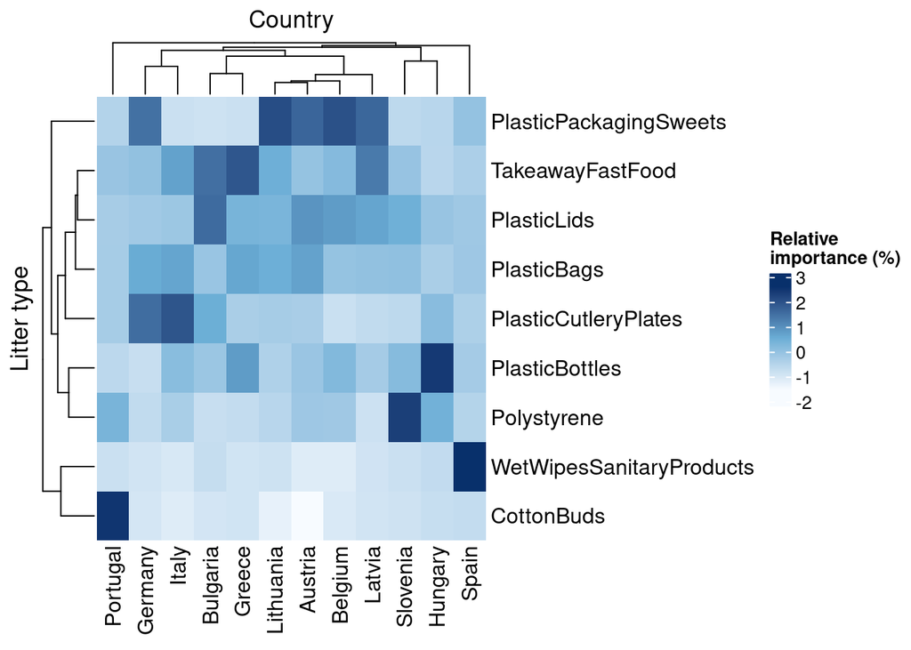

###### SUP Multivariate Perspective

In order to see if there are significant differences across country in the community composition, we will perform a PERMANOVA test:

```
## Permutation test for adonis under reduced model
## Marginal effects of terms
## Permutation: free
## Number of permutations: 999
##
## adonis2(formula = dist_mat_SUP ~ CountryResponsible, data = meta_SUP, permutations = 999, by = "margin")
##                     Df SumOfSqs      R2      F Pr(>F)
## CountryResponsible  11   23.275 0.10276 5.3932  0.001 ***
## Residual           518  203.232 0.89724
## Total              529  226.507 1.00000
## ---
## Signif. codes:  0 '***' 0.001 '**' 0.01 '*' 0.05 '.' 0.1 ' ' 1
```

So, we conclude that there are significant differences among countries. The R-Square value (0.103) means that the country “effects” explain 10.3% of the total variability. 89.7% is the remaining (unexplained) variability among countries. *There is a significant country effect, but is small*.

Or even better: **There are statistically significant multivariate differences in litter composition among countries, although the effect size is modest (R² = 0.103).**

We can look for **heterocedasticity** among countries

```
##
##  Homogeneity of multivariate dispersions
##
## Call: betadisper(d = dist_mat_SUP, group = meta_SUP$CountryResponsible)
##
## No. of Positive Eigenvalues: 9
## No. of Negative Eigenvalues: 0
##
## Average distance to median:
##   austria   belgium  bulgaria   germany    greece   hungary     italy    latvia
##    0.6174    0.5851    0.5416    0.5891    0.4907    0.5711    0.6384    0.4790
## lithuania  portugal  slovenia     spain
##    0.5726    0.6068    0.5959    0.6272
##
## Eigenvalues for PCoA axes:
## (Showing 8 of 9 eigenvalues)
##  PCoA1  PCoA2  PCoA3  PCoA4  PCoA5  PCoA6  PCoA7  PCoA8
## 62.576 39.391 35.044 29.197 22.517 18.480 10.848  6.789
```

```
##
## Permutation test for homogeneity of multivariate dispersions
## Permutation: free
## Number of permutations: 999
##
## Response: Distances
##            Df  Sum Sq  Mean Sq      F N.Perm Pr(>F)
## Groups     11  0.5355 0.048686 1.6889    999  0.071 .
## Residuals 518 14.9326 0.028827
## ---
## Signif. codes:  0 '***' 0.001 '**' 0.01 '*' 0.05 '.' 0.1 ' ' 1
```

The multivariate dispersion **does not differ significantly** among countries (betadisper; F = 1.69, p = 0.071), so the PERMANOVA result reflects differences in composition rather than in within-country variability. There is a Country effect but it is small.

If we need to parametrize this model, we should use a Mixed Multivariate Model (necessary?)

but What are the items that explains these differences?

The answer will be addressed by performing a **Multivariate Random Forest**.

```
##
## Call:
##  randomForest(x = comm_hel_SUP, y = as.factor(meta_SUP$CountryResponsible),      ntree = 500, importance = TRUE)
##                Type of random forest: classification
##                      Number of trees: 500
## No. of variables tried at each split: 3
##
##         OOB estimate of  error rate: 75.66%
## Confusion matrix:
##           austria belgium bulgaria germany greece hungary italy latvia
## austria        12       2        0      14      0       0     7      0
## belgium         3       3        1       9      0       0     3      0
## bulgaria        2       1        5       1      0       0     1      0
## germany         8       2        0      28      0       1     6      0
## greece          1       0        1       1      0       1     5      0
## hungary         1       1        1       1      0       3     3      0
## italy           6       3        0       6      1       2    17      0
## latvia          1       2        0       1      0       0     0      0
## lithuania       8      11        0      18      0       1     6      0
## portugal        7       2        0       6      0       0     5      0
## slovenia        5       1        0       2      1       0     4      0
## spain           9       9        1      18      0       1     9      0
##           lithuania portugal slovenia spain class.error
## austria          17        4        2    12   0.8285714
## belgium          14        3        0     8   0.9318182
## bulgaria          0        0        0     0   0.5000000
## germany          25        4        0     9   0.6626506
## greece            0        1        1     0   1.0000000
## hungary           3        2        0     0   0.8000000
## italy             4        0        2     9   0.6600000
## latvia            4        0        0     0   1.0000000
## lithuania        33        1        1     9   0.6250000
## portugal          8        6        1     8   0.8604651
## slovenia          5        4        1     1   0.9583333
## spain            12        1        3    21   0.7500000
```

Decisions have to be taken carefully since the prediction accuracy is very low (0.24). Furthermore, the estimated error rate (OOB) is high, so conclusion have to be taken with care.

Even though, the more important (differential across countries) litter components are:

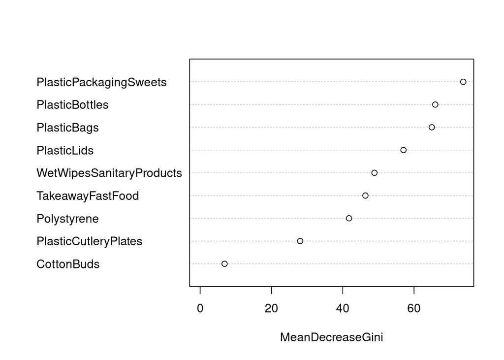

This plot of variable importance importance is telling us:

- A large `MeanDecreaseAccuracy` (**MDA**) means that, when you break the relationship between that predictor and the response, the model’s accuracy suffers a lot → it’s an important predictor for correct country assignments.
- **MDA** is generally the more reliable gauge of predictive importance, since it directly measures impact on OOB‐accuracy.
- A large `MeanDecreaseGini` (**MDG**) means that X frequently appears in high‑up the tree splits and yields big purity gains → it’s structurally important to partitioning the data.
  - **MDG** is faster to compute and tells you which features the trees “prefer” splitting on, but can overweight high–cardinality or continuous variables.

Finally, we will perform a Principal Component Analysis (PCA) to see correlation among litter items and *possible* associations with countries

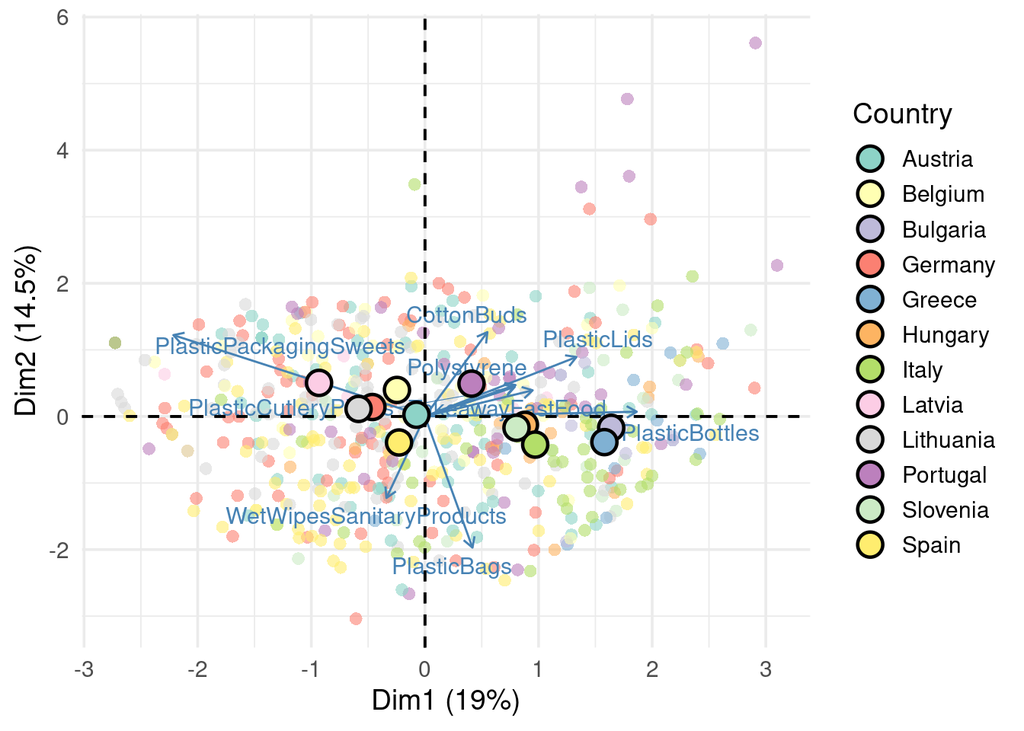

And the most important Items for the two forst principal components are:

- First PC

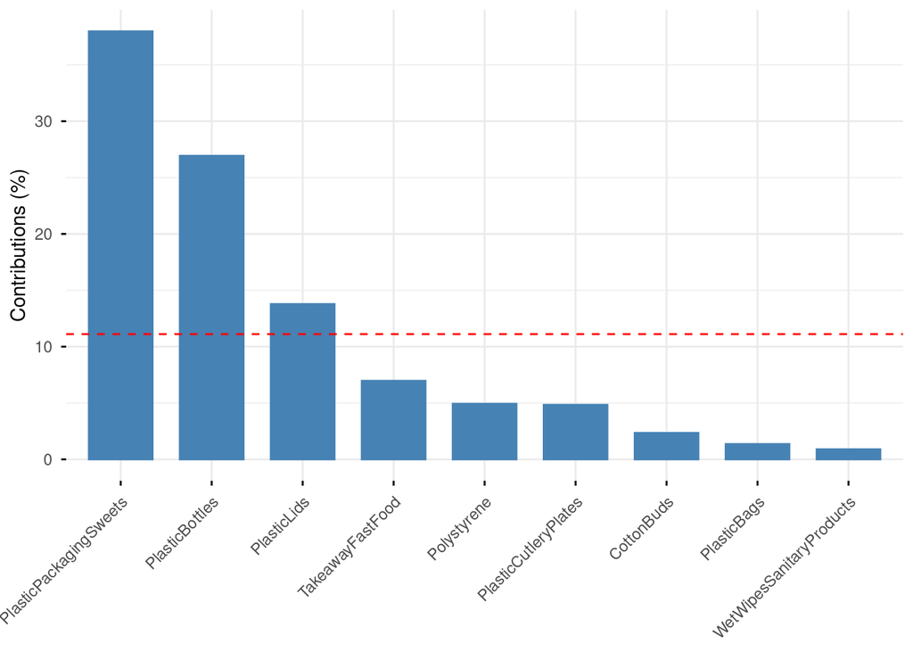

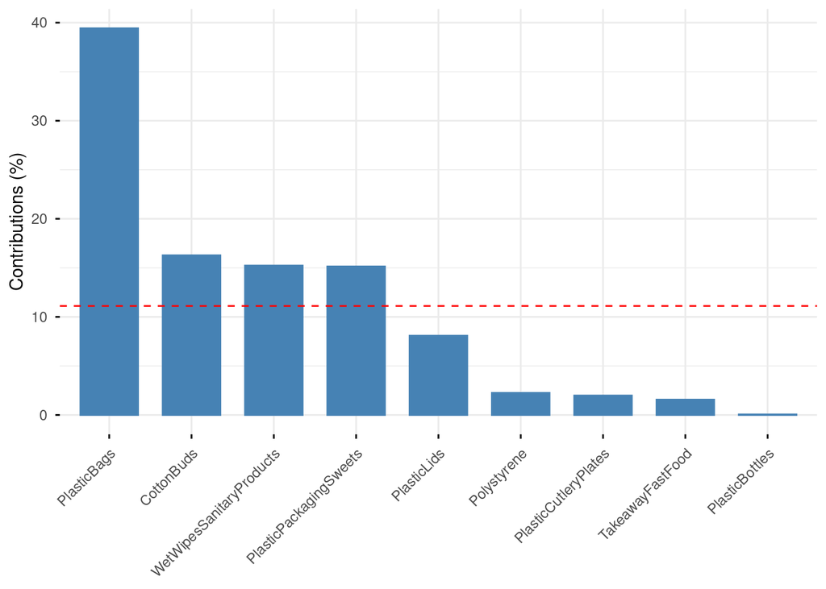

###### Manuscript values: Table 2 (PERMANOVA)

PERMANOVA results for the overall litter dataset (`perm1`) and the SUP subset (`perm1_SUP`), in the layout of Table 2 of the manuscript.

| Analysis | Term | df | SS | F | R2 | p_value |
| --- | --- | --- | --- | --- | --- | --- |
| Overall analysis | Country | 11 | 27.362 | 5.25 | 0.099 | 0.001 |
| Overall analysis | Residuals | 526 | 249.052 | NA | 0.901 | NA |
| Overall analysis | Total | 537 | 276.414 | NA | 1.000 | NA |
| Single-Use Plastics (SUP) | Country | 11 | 23.275 | 5.39 | 0.103 | 0.001 |
| Single-Use Plastics (SUP) | Residuals | 518 | 203.232 | NA | 0.897 | NA |
| Single-Use Plastics (SUP) | Total | 529 | 226.507 | NA | 1.000 | NA |

| Analysis | F | p_value |
| --- | --- | --- |
| Overall analysis | 6.90 | 0.001 |
| Single-Use Plastics (SUP) | 1.69 | 0.071 |

## Floating DATA

### Data loading

| DatasetID | CountryResponsible | SamplingYear | SamplingAttempted | DatasetQualified | SamplingDate | SamplingCoordinatesLatitude | SamplingCoordinatesLongitude | SamplingRiverSystem | FloatingMacro_AttemptedSampling | FloatingMacro_Qualified | FloatingMacro_ObservationTimeInMinutes | FloatingMacro_RiverWidth | FloatingMacro_ObservedWidth | FloatingMacro_AmountOfFloatingMacrolitter |
| --- | --- | --- | --- | --- | --- | --- | --- | --- | --- | --- | --- | --- | --- | --- |
| at_6270 | Austria | 2022 | 1 | 1 | 2022-10-18 | 48.04275 | 14.421917 | danube | 1 | 1 | 29.0 | 28 | 28 | 2 |
| at_6297 | Austria | 2022 | 1 | 1 | 2022-10-22 | 48.26034 | 13.034405 | danube | 1 | 1 | 30.0 | 195 | 6 | 0 |
| at_6349 | Austria | 2022 | 1 | 1 | 2022-10-19 | 48.07639 | 14.457147 | danube | 1 | 1 | 55.0 | 200 | 200 | 0 |
| at_6372 | Austria | 2022 | 1 | 1 | 2022-11-10 | 48.25968 | 13.034020 | danube | 1 | 1 | 60.0 | 11.21 | 11.33 | 1 |
| at_6382 | Austria | 2022 | 1 | 1 | 2022-11-08 | 47.11828 | 13.814191 | danube | 1 | 1 | 60.0 | 27 | 27 | 4 |
| at_6393 | Austria | 2022 | 1 | 1 | 2022-11-09 | 46.58301 | 13.841153 | danube | 1 | 1 | 30.0 | 21 | 7 | 0 |
| at_6414 | Austria | 2022 | 1 | 1 | 2022-11-11 | 48.22545 | 14.316103 | danube | 1 | 1 | 60.0 | 180 | 30 | 0 |
| at_6448 | Austria | 2022 | 1 | 1 | 2022-11-11 | 46.60477 | 14.278000 | danube | 1 | 1 | 30.0 | 9 | 9 | 7 |
| at_6703 | Austria | 2023 | 1 | 1 | 2023-05-10 | 48.38358 | 14.187583 | danube | 1 | 1 | 30.0 | 8 | 8 | 0 |
| at_6718 | Austria | 2023 | 1 | 1 | 2023-05-24 | 48.84332 | 15.500350 | danube | 1 | 1 | 30.0 | 27.7 | 13.85 | 0 |

[output cut: 365 more lines]

#### Sampling Effor for Floating Data

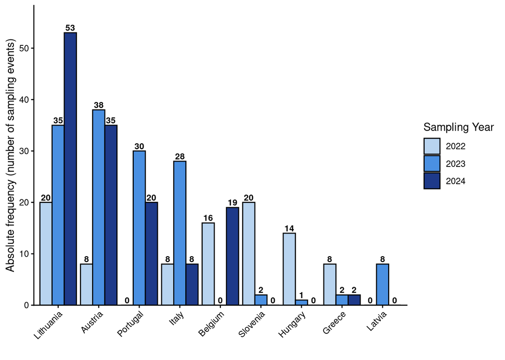

#### Macrolitter Flow calculation

The variable `FlowMacrolitter` is represented as the Number of floating macrolitter $m^{-1}$ $h^{-1}$.

| DatasetID | CountryResponsible | SamplingYear | SamplingAttempted | DatasetQualified | SamplingDate | SamplingCoordinatesLatitude | SamplingCoordinatesLongitude | SamplingRiverSystem | FloatingMacro_AttemptedSampling | FloatingMacro_Qualified | FloatingMacro_ObservationTimeInMinutes | FloatingMacro_RiverWidth | FloatingMacro_ObservedWidth | FloatingMacro_AmountOfFloatingMacrolitter | TimeInHours | RiverWidth | FlowMacrolitter |
| --- | --- | --- | --- | --- | --- | --- | --- | --- | --- | --- | --- | --- | --- | --- | --- | --- | --- |
| at_6270 | Austria | 2022 | 1 | 1 | 2022-10-18 | 48.04275 | 14.421917 | danube | 1 | 1 | 29.0 | 28 | 28 | 2 | 0.4833333 | 62 | 0.066740823 |
| at_6297 | Austria | 2022 | 1 | 1 | 2022-10-22 | 48.26034 | 13.034405 | danube | 1 | 1 | 30.0 | 195 | 6 | 0 | 0.5000000 | 98 | 0.000000000 |
| at_6349 | Austria | 2022 | 1 | 1 | 2022-10-19 | 48.07639 | 14.457147 | danube | 1 | 1 | 55.0 | 200 | 200 | 0 | 0.9166667 | 47 | 0.000000000 |
| at_6372 | Austria | 2022 | 1 | 1 | 2022-11-10 | 48.25968 | 13.034020 | danube | 1 | 1 | 60.0 | 11.21 | 11.33 | 1 | 1.0000000 | 17 | 0.058823529 |
| at_6382 | Austria | 2022 | 1 | 1 | 2022-11-08 | 47.11828 | 13.814191 | danube | 1 | 1 | 60.0 | 27 | 27 | 4 | 1.0000000 | 60 | 0.066666667 |
| at_6393 | Austria | 2022 | 1 | 1 | 2022-11-09 | 46.58301 | 13.841153 | danube | 1 | 1 | 30.0 | 21 | 7 | 0 | 0.5000000 | 103 | 0.000000000 |
| at_6414 | Austria | 2022 | 1 | 1 | 2022-11-11 | 48.22545 | 14.316103 | danube | 1 | 1 | 60.0 | 180 | 30 | 0 | 1.0000000 | 69 | 0.000000000 |
| at_6448 | Austria | 2022 | 1 | 1 | 2022-11-11 | 46.60477 | 14.278000 | danube | 1 | 1 | 30.0 | 9 | 9 | 7 | 0.5000000 | 119 | 0.117647059 |
| at_6703 | Austria | 2023 | 1 | 1 | 2023-05-10 | 48.38358 | 14.187583 | danube | 1 | 1 | 30.0 | 8 | 8 | 0 | 0.5000000 | 110 | 0.000000000 |
| at_6718 | Austria | 2023 | 1 | 1 | 2023-05-24 | 48.84332 | 15.500350 | danube | 1 | 1 | 30.0 | 27.7 | 13.85 | 0 | 0.5000000 | 25 | 0.000000000 |

[output cut: 365 more lines]

#### Macrolitter Flow Visualization

##### Differences across countries

Notes on the figures:

- **All sampling years are always shown** for every country. Country-year combinations without valid data are labelled **n.d.** (no data). This covers both years without floating samplings and years where the flow could not be calculated (e.g. the river width is missing).
- The number above each box is the number of valid samplings (*n*).
- Most flow values are exactly 0, so the y-axis uses a **square-root scale**. This spreads out the small values near zero while keeping the zeros, which a log scale cannot show. All observations are drawn as points over the boxes.
- No observations are removed from the plot. The previous version used `scale_y_continuous(limits = c(0, 1))`, which **dropped** the values above 1 before computing the boxplots.

| CountryResponsible | SamplingYear | n_samplings | n_valid | label |
| --- | --- | --- | --- | --- |
| Austria | 2022 | 8 | 8 | 8 |
| Austria | 2023 | 38 | 36 | 36 |
| Austria | 2024 | 35 | 33 | 33 |
| Belgium | 2022 | 16 | 0 | n.d. |
| Belgium | 2023 | 0 | 0 | n.d. |
| Belgium | 2024 | 19 | 18 | 18 |
| Greece | 2022 | 8 | 8 | 8 |
| Greece | 2023 | 2 | 2 | 2 |
| Greece | 2024 | 2 | 1 | 1 |
| Hungary | 2022 | 14 | 8 | 8 |

[output cut: 17 more lines]

- Boxplots per country, with the sampling years nested within each country on the x-axis:

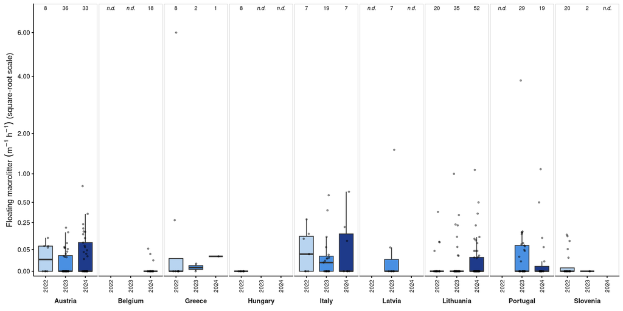

- Same data with one panel per sampling year (`facet_grid`), to compare countries within each year:

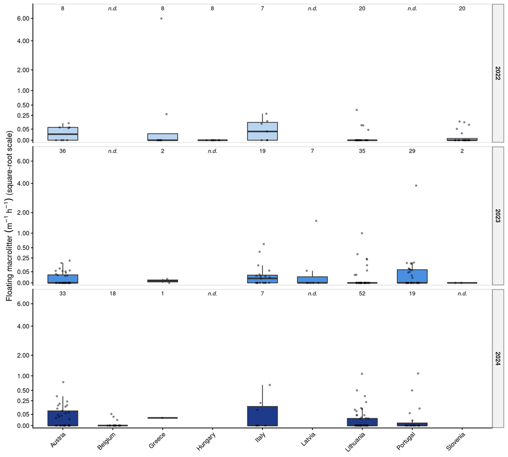

###### Manuscript values: low floating macrolitter densities

| CountryResponsible | n | Median | Mean | SE | Q75 | Max |
| --- | --- | --- | --- | --- | --- | --- |
| Austria | 77 | 0.000 | 0.047 | 0.012 | 0.059 | 0.764 |
| Belgium | 18 | 0.000 | 0.005 | 0.003 | 0.000 | 0.054 |
| Greece | 11 | 0.000 | 0.573 | 0.543 | 0.015 | 6.000 |
| Hungary | 8 | 0.000 | 0.000 | 0.000 | 0.000 | 0.000 |
| Italy | 33 | 0.008 | 0.086 | 0.029 | 0.098 | 0.667 |
| Latvia | 7 | 0.000 | 0.231 | 0.221 | 0.030 | 1.556 |
| Lithuania | 107 | 0.000 | 0.051 | 0.016 | 0.009 | 1.083 |
| Portugal | 48 | 0.000 | 0.139 | 0.083 | 0.063 | 3.833 |
| Slovenia | 22 | 0.000 | 0.020 | 0.009 | 0.000 | 0.141 |

| CountryResponsible | SamplingYear | n | Median | Max |
| --- | --- | --- | --- | --- |
| Belgium | 2024 | 18 | 0.000 | 0.054 |
| Greece | 2022 | 8 | 0.000 | 6.000 |
| Greece | 2023 | 2 | 0.003 | 0.006 |
| Greece | 2024 | 1 | 0.024 | 0.024 |
| Hungary | 2022 | 8 | 0.000 | 0.000 |
| Latvia | 2023 | 7 | 0.000 | 1.556 |

- **Statistical test**
  - Generalize linear mixed model (Tweedie)

  Family error distribution was selected due to the data restriction (only positive values with high numbers of zeroes)

```
##  Family: tweedie  ( log )
## Formula:          FlowMacrolitter ~ CountryResponsible
## Data: FlowData
##
##       AIC       BIC    logLik -2*log(L)  df.resid
##     290.0     331.8    -134.0     268.0       320
##
##
## Dispersion parameter for tweedie family (): 2.16
##
## Conditional model:
##                               Estimate Std. Error z value Pr(>|z|)
## (Intercept)                    -3.0551     0.3049 -10.018  < 2e-16 ***
## CountryResponsibleBelgium      -2.1601     1.0099  -2.139   0.0324 *
## CountryResponsibleGreece        2.4984     0.5812   4.299 1.72e-05 ***
## CountryResponsibleHungary     -49.0697 22469.0664  -0.002   0.9983
## CountryResponsibleItaly         0.6001     0.5143   1.167   0.2433
## CountryResponsibleLatvia        1.5887     0.8014   1.982   0.0474 *
## CountryResponsibleLithuania     0.0708     0.3976   0.178   0.8587
## CountryResponsiblePortugal      1.0816     0.4367   2.477   0.0132 *
## CountryResponsibleSlovenia     -0.8575     0.7405  -1.158   0.2469
## ---
## Signif. codes:  0 '***' 0.001 '**' 0.01 '*' 0.05 '.' 0.1 ' ' 1
```

|  | Df | AIC | BIC | logLik | deviance | Chisq | Chi Df | Pr(>Chisq) |
| --- | --- | --- | --- | --- | --- | --- | --- | --- |
| mod_null | 3 | 318.2739 | 329.6803 | -156.1370 | 312.2739 | NA | NA | NA |
| mod_full | 11 | 290.0082 | 331.8315 | -134.0041 | 268.0082 | 44.26567 | 8 | 5.068326e-07 |

- Posthoc with multple comparisons

|  | contrast | ratio | SE | df | null | z.ratio | p.value |
| --- | --- | --- | --- | --- | --- | --- | --- |
| 1 | Austria / Belgium | 8.671752e+00 | 8.757255e+00 | Inf | 1 | 2.138980600 | 0.4464309150 |
| 2 | Austria / Greece | 8.221540e-02 | 4.778022e-02 | Inf | 1 | -4.299017260 | 0.0005807215 |
| 3 | Austria / Hungary | 2.045041e+21 | 4.595016e+25 | Inf | 1 | 0.002183878 | 1.0000000000 |
| 4 | Austria / Italy | 5.487760e-01 | 2.822611e-01 | Inf | 1 | -1.166654849 | 0.9633969547 |
| 5 | Austria / Latvia | 2.041962e-01 | 1.636342e-01 | Inf | 1 | -1.982478005 | 0.5556861400 |
| 6 | Austria / Lithuania | 9.316487e-01 | 3.704281e-01 | Inf | 1 | -0.178064822 | 0.9999999697 |
| 7 | Austria / Portugal | 3.390504e-01 | 1.480505e-01 | Inf | 1 | -2.476986158 | 0.2431155310 |
| 8 | Austria / Slovenia | 2.357258e+00 | 1.745566e+00 | Inf | 1 | 1.157989249 | 0.9649953461 |
| 9 | Belgium / Greece | 9.480830e-03 | 1.026196e-02 | Inf | 1 | -4.303883306 | 0.0005683707 |
| 10 | Belgium / Hungary | 2.358279e+20 | 5.298832e+24 | Inf | 1 | 0.002087743 | 1.0000000000 |

[output cut: 26 more lines]